# day3_piano

**piano** support many gene set-level statistics. It accepts input as matrix or as a vector of gene-level scores. In this example, we use the pre-computed gene-level scores which is the t-value in a two-condition comparison:

```r
library(CePa)
condition = read.cls("P53.cls", treatment = "MUT", control = "WT")$label
expr = read.gct("P53_collapsed_symbols.gct")

library(genefilter)
s = rowttests(expr, factor(condition))[, "statistic"]
names(s) = rownames(expr)
```

We use the hallmark gene sets from MSigDB.

```r
library(msigdbr)
gs = msigdbr(category = "H")
```

**piano** needs the gene sets data to be stored in a object in a specific format:

```r
library(piano)
gs = loadGSC(gs[, c("gene_symbol", "gs_name")])
```

`runGSA()` runs GSEA analysis. The default gene-set-level method is “mean” (take the mean of gene-level statistics).

Note since the input is a vector of gene-level scores, p-values are calculated based on gene permutation.

```r
res = runGSA(geneLevelStats = s, gsc = gs)
```

```
## Checking arguments...done!
## Adjusting for multiple testing...done!
```

`exploreGSAres()` visualizes the results via a Shiny app.

The result table can be extracted with `GSAsummaryTable()`:

```r
res_tb = GSAsummaryTable(res)
head(res_tb)
```

```
##                           Name Genes (tot) Stat (dist.dir) p (dist.dir.up)
## 1        HALLMARK_ADIPOGENESIS         129       -0.082516        0.066493
## 2 HALLMARK_ALLOGRAFT_REJECTION         168       -0.552630        1.000000
## 3   HALLMARK_ANDROGEN_RESPONSE          75       -0.013721        0.043896
## 4        HALLMARK_ANGIOGENESIS          33       -0.196350        0.432560
## 5     HALLMARK_APICAL_JUNCTION         148       -0.094170        0.063794
## 6      HALLMARK_APICAL_SURFACE          26       -0.313330        0.651730
##   p adj (dist.dir.up) p (dist.dir.dn) p adj (dist.dir.dn) Stat (non-dir.)
## 1             0.18051      0.93361000           1.0000000         0.95258
## 2             1.00000      0.00009999           0.0049995         0.97740
## 3             0.13717      0.95620000           1.0000000         0.83419
## 4             0.65539      0.56754000           1.0000000         0.74358
## 5             0.18051      0.93631000           1.0000000         0.93633
## 6             0.80151      0.34837000           1.0000000         0.72858
##   p (non-dir.) p adj (non-dir.) Genes (up) Stat (mix.dir.up) p (mix.dir.up)
```

[output cut: 20 more lines]

`runGSA()` can only run a single method. Here we use `lapply()` to run multiple methods:

```r
all_set_stats = c("mean", "median", "fgsea", "page")
res_list = lapply(all_set_stats, function(stat) {
    runGSA(geneLevelStats = s, gsc = gs, geneSetStat = stat)
})
names(res_list) = all_set_stats
```

There is a `consensusHeatmap()` function in **piano** which draws a heatmap of the top gene sets by averaging ranks from multiple methods.

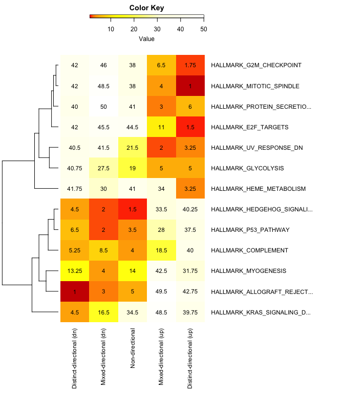

```r
consensusHeatmap(res_list, method = "mean")
```

```r
p_list = lapply(res_list, function(x) {
    GSAsummaryTable(x)[, 3]
})
```

If we use **ComplexHeatmap** for heatmaps.

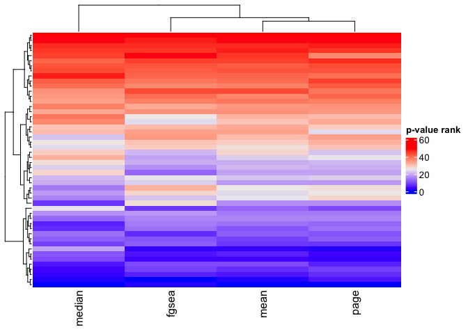

```r
library(ComplexHeatmap)
rank_mat = do.call(cbind, lapply(p_list, rank))
Heatmap(rank_mat, name = "p-value rank")
```